# Análise de Conteúdo em Conselhos Gestores com R

# Análise de Conteúdo em R

### 1. Instalando e carregando pacotes

```r
# instalar pacotes para a análise
install.packages(c("RQDA", "readxl", "readr", "stringi", "stringr", "plyr", "dplyr", "ggplot2"))
```

```r
# carregar pacotes
library(readxl); library(ggplot2); library(readr); library(stringi);
library(stringr); library(plyr); library(dplyr); library(RQDA)
```

### 2. R Qualitativa Data Analysis (RQDA)

RQDA é um pacote R para performar análises de dados qualitativas, mais especificamente para análise de textos. Sua principal funcionalidade é a codificação de textos, em que no caso aqui apresentado servirá para identificar (1) temas de debate nas reuniões, (2) situações de fala dos representantes. Com a incorporação de outras técnicas como análise de redes podemos identificar também a proximidade entre grupos e temas específicos. Abaixo segue orientações de como utilizar o pacote e em seguida alguns exemplos

```r
# executar o pacote RQDA
library(RQDA)
RQDA()
```

Após carregar e executar o pacote, será berta uma janela externa. Crie um novo projeto e nomei-o como desejar. Em seguido será mostrado as opções do projeto. Vá em “Files” e em seguida importe o arquivo .txt que será analisado.

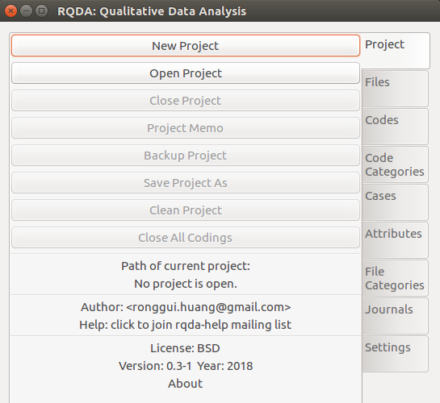

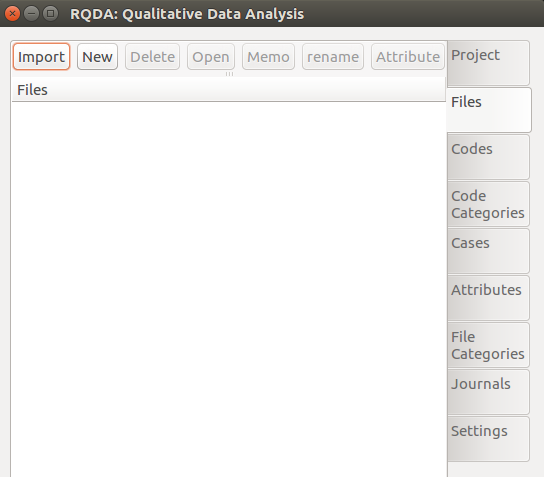

Após importados os arquivos vá em codes e crie os códigos necessários para sua análise. No caso implementado foram utilizados códigos relativos aos temas de debate e também cada representante recebeu um código, de forma que ao final da codificação haja uma contagem de quantas vezes foram debatidos cada tema e quantas vezes cada representante levantou voz no Conselho. Para codificar, selecione com o cursor do mouse o texto para codificação e clique em “Mark”.

[figure not shown]

### 2.1 Saliência de Temas

Após as codificações completadas as codificações dos temas debatidos nas reuniões, é possível responder à pergunta “quais são os temas mais e menos debatidos nas reuniões do Conselho”. Essa informação reflete qual o foco do Conselho de modo a identificar quais temas são mais salientes ou problemáticos para os atores do contexto em questão. Abaixo seguem os códigos necessários para capturar as informações relativas aos códigos.

```r
# capturar informacoes dos codigos
sumario_cod <- summaryCodings()

# selecionar contagem de cada codigo
cont_cod_data <- data.frame(sumario_cod$NumOfCoding)
```

```r
# selecionar codigos relativos ao tema
cont_cod_tema <- cont_cod_data[str_detect(cont_cod_data$Var1, "tema_"),]

# visualizar base
cont_cod_tema
```

```
## # A tibble: 7 x 2
##   Var1                           Freq
##   <chr>                         <dbl>
## 1 tema_Conselho                    63
## 2 tema_Educação_Ambiental          17
## 3 tema_Fiscalização_e_Regulação    30
## 4 tema_Gestão_APACC                27
## 5 tema_Plano_de_Manejo              8
## 6 tema_Recursos_Financeiros        13
## 7 tema_Zoneamento                  16
```

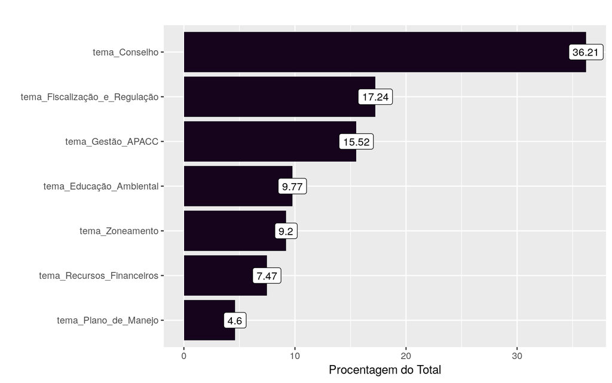

```r
# criar variavel de  proporcao de cada tema em relacao ao total
cont_cod_tema <- mutate(cont_cod_tema, prop_tema = round((Freq / sum(Freq))*100, 2) )

# ordenar os valores
cont_cod_tema$Var1 <- factor(cont_cod_tema$Var1,
                             levels = cont_cod_tema$Var1[order(cont_cod_tema$prop_tema)])

# visualizar graficamente e salvar
ggplot(cont_cod_tema, aes(x = Var1, y = prop_tema))+
  geom_bar(stat = "identity", fill = "#15041c") +
  geom_label(aes(x = Var1, y = prop_tema, label = prop_tema), size = 3.5)+
  labs(y = "Procentagem do Total", x = "", title = "") +
  coord_flip()
```

```r
  ggsave("prop_debate_tema.png", path = "results",width = 7, height = 3, units = "in")
```

### 2.2 Proporção de Fala

Outra possibilidade é a contagem de situções de fala por grupo de interesse. Isso é de extrema importância e uma análise inovadora visto que a maioria das análises de participação consideram apenas a presença dos representantes em plenária, enquanto a preponderância da fala fica à margem. A fala assume um caráter essencial no debate público, visto que é a partir da racionalização discursiva e do processo comunicativo que os atores conseguem chegar a decisões coletivas (HABERMAS).

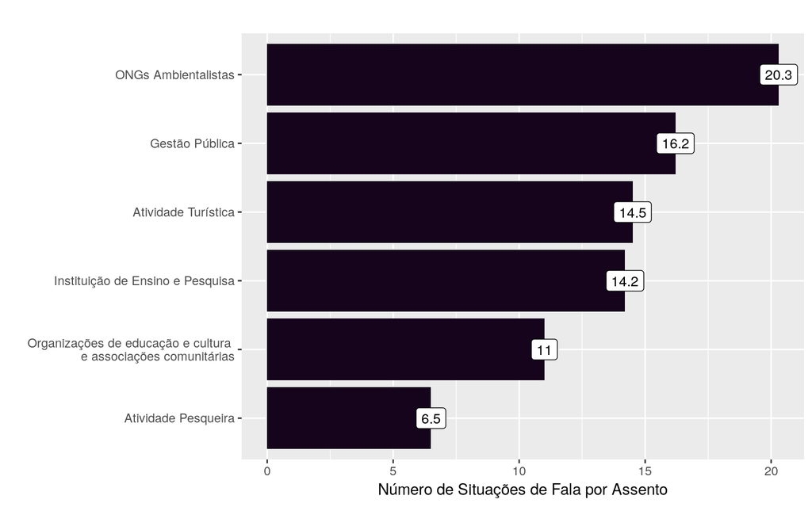

```r
# selecionar codigos que nao sao de representantes
paste_voz<- c("cat_", "tema_", "DESTAQUES", "DUVIDA_", "atua_", "DECISOES", "termo_", "tema2_", "IDENT_MEMO")
cont_cod_rep <- cont_cod_data[!str_detect(cont_cod_data$Var1, paste(paste_voz, collapse = '|')),]

# Carregar base de dados de conselheiros e categorias das suas respectivas intituicoes
representantes_instituicoes_apacc <- read_excel("data/representantes_instituicoes_apacc.xlsx")

# funcao para padronizar nomes
cleanString <- function(x){
  library(plyr); library(stringi); library(stringr)
  x_mani = stri_trans_general(x, "Latin-ASCII")%>%
    str_replace_all("_", " ")%>%
    tolower()
  return(x_mani)
}

# executa funcao
representantes_instituicoes_apacc$nome_consel <- cleanString(representantes_instituicoes_apacc$nome_consel)
cont_cod_rep$nome_consel <- cleanString(cont_cod_rep$Var1)

# mergir bases
participaData <- merge(cont_cod_rep, representantes_instituicoes_apacc, by = "nome_consel")

# retirar contagem do presidente do conselho e dos analistas*
participaData <- participaData[participaData$entidade_sigla != "ICMBIO",]

# contagem por grupo
participa_cont <- aggregate(participaData$Freq, by=list(Category=participaData$categoria1), FUN=sum)

# inserir info de assentos na base
participa_cont$numero_assentos <- c(6, 6, 12, 8, 3, 3)

# calcular proporcionalidade
participa_cont <- mutate(participa_cont, participaProp = round((x/numero_assentos),1))

# renomear para grafico
participa_cont$Category <- as.character(participa_cont$Category)
participa_cont$Category[6] <- "Organizações de educação e cultura \n e associações comunitárias"

# ordenar
participa_cont$Category <- factor(participa_cont$Category,
                              levels = participa_cont$Category[order(participa_cont$participaProp)])
# grafico comparativo
ggplot(participa_cont, aes(x = Category, y = participaProp))+
  geom_bar(stat = "identity", fill = "#15041c") +
  geom_label(aes(label = participaProp), size = 3.5)+
  labs(y = "Número de Situações de Fala por Assento", x = "", title = "") +
  coord_flip()+
 ggsave("prop_voz_cat.png", path = "results", width = 8, height = 3, units = "in")
```

Cláudio Monteiro

2020